# Final Project HUDM 6026

Getong Zhong & Frank Li

2023-05-02

## 1. Select a motivating data set

Our main focus on this project is analyzing Walmart’s sales records. Walmart, being one of the most recognized retail in the U.S., has a vast amount of data at its disposal. The data set we have chosen spans from 2010 to 2012 and contains the weekly sales records from 45 different Walmart stores and it is publicly available on Kaggle.

For our analysis, we plan to utilize a numeric outcome variable and a numeric predictor variable. The numeric outcome variable will be the weekly sales, which is a continuous variable. On the other hand, the numeric predictor variable could be one or multiple factors, including the Consumer Price Index (CPI), Unemployment Index, Temperature, Fuel price, and Holiday Index (whether the week is a special holiday week). Due to the requirement of this project, we only include CPI as the only predictor to make our model a simple linear regression model.

## 2. Data generation

Data generation part in this project in quite straightforward. We are going to simulate data from the simple linear regression model we create for the “Walmart_Store_sales” data set,with “Weekly_Sales” as the response variable and “CPI” as the predictor. After We got the value of intercept, and slope for the predictor from the model summary, we are going to record it for latter use in the data generation function to generate our own data from the real-life data.

```r
# Import data set
data <- read.csv("Walmart_Store_sales.csv", header = TRUE)
# Run a simple linear regression model
model <- lm (Weekly_Sales ~ CPI, data = data)
summary(model)
```

```
##
## Call:
## lm(formula = Weekly_Sales ~ CPI, data = data)
##
## Residuals:
##     Min      1Q  Median      3Q     Max
## -883689 -480911 -112047  385944 2783144
##
## Coefficients:
##              Estimate Std. Error t value Pr(>|t|)
## (Intercept) 1225673.7    31389.4  39.047  < 2e-16 ***
## CPI           -1041.6      178.3  -5.841 5.44e-09 ***
## ---
## Signif. codes:  0 '***' 0.001 '**' 0.01 '*' 0.05 '.' 0.1 ' ' 1
##
## Residual standard error: 562900 on 6433 degrees of freedom
## Multiple R-squared:  0.005276,   Adjusted R-squared:  0.005121
## F-statistic: 34.12 on 1 and 6433 DF,  p-value: 5.438e-09
```

```r
dat_gen <- function(n, beta_0, beta_1, x_dist, sigma) {
  # create new random variable
  x1 <- x_dist(n)
  # create new response variable
  y <- beta_0 + beta_1 * x1 + rnorm(n, mean = 0, sd = sigma)
  return(data.frame(X1 = x1, Weekly_sales = y))
}

data_simulation <- dat_gen(n = nrow(data), beta_0 = model$coefficients[1], beta_1 = model$coefficients[2], x_dist = rnorm, sigma = summary(model)$sigma)
data_simulation
```

```
##                 X1 Weekly_sales
## 1    -1.419809e+00  1360482.344
## 2     3.885113e-01  1184731.701
## 3    -1.017411e-01   889035.096
## 4     5.446458e-01  1212741.217
## 5     4.736974e-02  1647210.522
## 6    -1.085841e+00  1631387.649
## 7    -5.010757e-02   682613.184
## 8     3.774506e-01   990089.927
## 9     2.573406e+00   413058.662
## 10    2.106327e+00  1111160.851
## 11    4.067087e-01  1577054.216
## 12    1.028983e+00   720768.961
## 13    1.806740e+00   968741.978
## 14    2.143937e-01   905495.411
```

[output cut: 6421 more lines]

## 3. Estimators

In this section, we have developed a function, reg(), constructed entirely from scratch. This function ingests a data frame generated from the dat_gen() function and outputs estimates for two key parameters: the slope on X (denoted as beta1) and the error variance (denoted as sigma squared).

To generate these estimates, we have utilized two different estimators for each parameter. The first estimator for beta1 is the least squares estimator. It minimizes the sum of the squared residuals, providing the best linear unbiased estimate.

The second estimator for sigma squared is an alternative estimator. This estimator divides the sum of squared errors by the sample size (n), rather than by the degree of freedom. This is a more direct estimate of the average of squared errors.

These estimators enable us to obtain key parameters for our regression model, thereby allowing us to better understand the relationship between our predictor and response variables.

```r
reg <- function(data) {
  n <- nrow(data)
  xbar <- mean(data[,1])
  ybar <- mean(data[,2])
  # estimate beta1 using the least squares estimator
  beta1 <- sum((data[,1] - xbar) * (data[,2] - ybar)) / sum((data[,1] - xbar)^2)

  # estimate beta1 using the alternative estimator
  beta1a <- 1 / mean((data[,2] - ybar) / (data[,1] - xbar))

  # estimate sigma^2 using the usual estimator
  sig2 <- sum((data[,2] - predict(lm(Weekly_sales ~ X1, data = data))^2) / (n - 2))

  # estimate sigma^2 using the alternative estimator
  sig2a <- sum((data[,2] - predict(lm(Weekly_sales ~ X1, data = data)))^2) / n

  return(list(beta1a = beta1,
              beta1_a = beta1a,
              sigma2 = sig2,
              sigma2a = sig2a))
}
```

### New data

```r
reg_results <- reg(data_simulation)
reg_results
```

```
## $beta1a
## [1] -7169.151
##
## $beta1_a
## [1] -5.681832e-08
##
## $sigma2
## [1] -1.484365e+12
##
## $sigma2a
## [1] 316781558887
```

## 4. Monte Carlo simulation

```r
library(plotrix)
n = 40
R = 1000

# Define the true values of the parameters
beta_0 <- model$coefficients[1]
beta_1 <- model$coefficients[2]
sigma <- summary(model)$sigma

# Run the Monte Carlo simulation using replicate()
dat_list <- replicate(n = R, expr = dat_gen(n = n, beta_0 = beta_0, beta_1 = beta_1, x_dist = rnorm, sigma = summary(model)$sigma),simplify = FALSE)
head(dat_list)
```

```
## [[1]]
##             X1 Weekly_sales
## 1   0.20821987    1305819.5
## 2  -1.60949749    1198399.2
## 3   3.17173360    1246629.6
## 4  -2.92453400    1463708.8
## 5  -2.09678836    1163638.1
## 6   0.53486659     674504.5
## 7  -1.54618075     740429.7
## 8   0.17560972    1961803.6
## 9  -0.14339537    1336139.3
## 10  0.86769121    1549894.2
## 11 -0.40178159     917036.3
## 12  0.10558004     811243.2
## 13 -0.39317634    1067269.4
```

[output cut: 242 more lines]

```r
reg_results2 <- lapply(dat_list, reg)
head(reg_results2)
```

```
## [[1]]
## [[1]]$beta1a
## [1] -33056.95
##
## [[1]]$beta1_a
## [1] 1.030826e-06
##
## [[1]]$sigma2
## [1] -1.720077e+12
##
## [[1]]$sigma2a
## [1] 330733803328
##
##
## [[2]]
## [[2]]$beta1a
## [1] -32782.26
##
## [[2]]$beta1_a
## [1] 2.275261e-06
##
## [[2]]$sigma2
## [1] -1.729014e+12
##
## [[2]]$sigma2a
## [1] 319317357099
##
##
## [[3]]
## [[3]]$beta1a
## [1] -2197.056
##
## [[3]]$beta1_a
## [1] 1.438632e-06
##
## [[3]]$sigma2
## [1] -1.147155e+12
##
## [[3]]$sigma2a
## [1] 302702761283
```

[output cut: 27 more lines]

```
## [1] 2.91593e+11
##
##
## [[6]]
## [[6]]$beta1a
## [1] -46698.3
##
## [[6]]$beta1_a
## [1] -2.083095e-06
##
## [[6]]$sigma2
## [1] -1.51648e+12
##
## [[6]]$sigma2a
## [1] 301799765746
```

### Calculate and report the mean and the standard error of the mean for each parameter and for each estimator based on the Monte Carlo replications. Estimate the bias, variance and MSE of each estimator.

### Means and stadard error for each estimator based on Monte carlo replications

```r
library(plotrix)
result <- do.call(rbind, lapply(reg_results2, unlist))
means <- colMeans(result)
std.error(result)
```

```
##       beta1a      beta1_a       sigma2      sigma2a
## 2.850369e+03 1.905220e-05 7.242075e+09 2.160369e+09
```

```r
means
```

```
##        beta1a       beta1_a        sigma2       sigma2a
## -1.390055e+03 -3.090778e-06 -1.605068e+12  3.000415e+11
```

### Estimate the bias, variance and MSE of each estimator.

```r
bias_beta1a <- means['beta1a'] - reg_results$beta1a
bias_beta1_a <- means['beta1_a'] - reg_results$beta1_a
bias_sigama2 <- means['sigama2'] - reg_results$sigama2
bias_sigama2a <- means['sigama2a'] - reg_results$sigama2a
bias <- c(bias_beta1a,bias_beta1_a,bias_sigama2,bias_sigama2a)
bias
```

```
##        beta1a       beta1_a
##  5.779096e+03 -3.033960e-06
```

```r
var <- apply(result, 2, var)
var
```

```
##       beta1a      beta1_a       sigma2      sigma2a
## 8.124605e+09 3.629863e-07 5.244765e+22 4.667194e+21
```

```r
mse <- bias^2 + var
mse
```

```
##       beta1a      beta1_a       sigma2      sigma2a
## 8.158003e+09 3.629955e-07 5.244765e+22 4.667194e+21
```

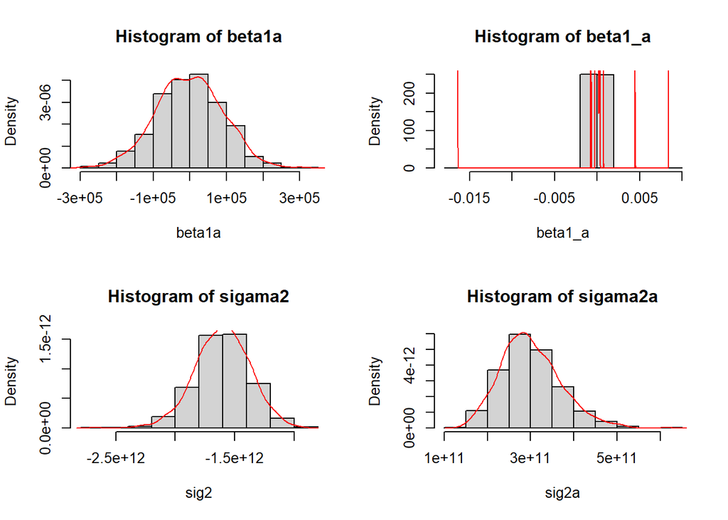

```r
beta1a <- sapply(reg_results2, function(x) x$beta1a)
beta1_a <- sapply(reg_results2, function(x) x$beta1_a)
sig2 <- sapply(reg_results2, function(x) x$sigma2)
sig2a <- sapply(reg_results2, function(x) x$sigma2a)
par(mfrow = c(2, 2))

hist(beta1a, freq = FALSE, main = "Histogram of beta1a")
lines(density(beta1a), col = "red")

hist(beta1_a, freq = FALSE, main = "Histogram of beta1_a")
lines(density(beta1_a), col = "red")

hist(sig2, freq = FALSE, main = "Histogram of sigama2")
lines(density(sig2), col = "red")

hist(sig2a, freq = FALSE, main = "Histogram of sigama2a")
lines(density(sig2a), col = "red")
```

## 5. Bootstrap

```r
n = 40
B = 500
dat_list1 <- replicate(n = n,
                      expr = dat_gen(n = n, beta_0 = beta_0, beta_1 = beta_1, x_dist = rnorm, sigma = summary(model)$sigma),
                      simplify = FALSE)

reg_results3 <- lapply(dat_list1, reg)
head(reg_results3)
```

```
## [[1]]
## [[1]]$beta1a
## [1] 1981.075
##
## [[1]]$beta1_a
## [1] 3.396594e-07
##
## [[1]]$sigma2
## [1] -1.419845e+12
##
## [[1]]$sigma2a
## [1] 328385160336
##
##
## [[2]]
## [[2]]$beta1a
## [1] 65749.12
##
## [[2]]$beta1_a
## [1] 1.515133e-06
##
## [[2]]$sigma2
## [1] -1.666583e+12
##
## [[2]]$sigma2a
## [1] 288656483902
##
##
## [[3]]
## [[3]]$beta1a
## [1] 23959.77
##
## [[3]]$beta1_a
## [1] -4.177063e-07
##
## [[3]]$sigma2
## [1] -1.629479e+12
##
## [[3]]$sigma2a
## [1] 264534755663
```

[output cut: 27 more lines]

```
## [1] 192378396225
##
##
## [[6]]
## [[6]]$beta1a
## [1] -181425.6
##
## [[6]]$beta1_a
## [1] 9.702181e-07
##
## [[6]]$sigma2
## [1] -1.760481e+12
##
## [[6]]$sigma2a
## [1] 246779189382
```

```r
result1 <- do.call(rbind, lapply(reg_results3, unlist))
means <- colMeans(result1)
std.error(result1)
```

```
##       beta1a      beta1_a       sigma2      sigma2a
## 1.379129e+04 1.021166e-06 3.405055e+10 1.182342e+10
```

```r
bias_beta1a <- means['beta1a'] - reg_results$beta1a
bias_beta1_a <- means['beta1_a'] - reg_results$beta1_a
bias_sigama2 <- means['sigama2'] - reg_results$sigama2
bias_sigama2a <- means['sigama2a'] - reg_results$sigama2a
bias <- c(bias_beta1a,bias_beta1_a,bias_sigama2,bias_sigama2a)
bias
```

```
##       beta1a      beta1_a
## 1.314751e+04 1.488835e-06
```

```r
var <- apply(result1, 2, var)
var
```

```
##       beta1a      beta1_a       sigma2      sigma2a
## 7.607993e+09 4.171122e-11 4.637759e+22 5.591728e+21
```

```r
mse <- bias^2 + var
mse
```

```
##       beta1a      beta1_a       sigma2      sigma2a
## 7.780850e+09 4.392785e-11 4.637759e+22 5.591728e+21
```

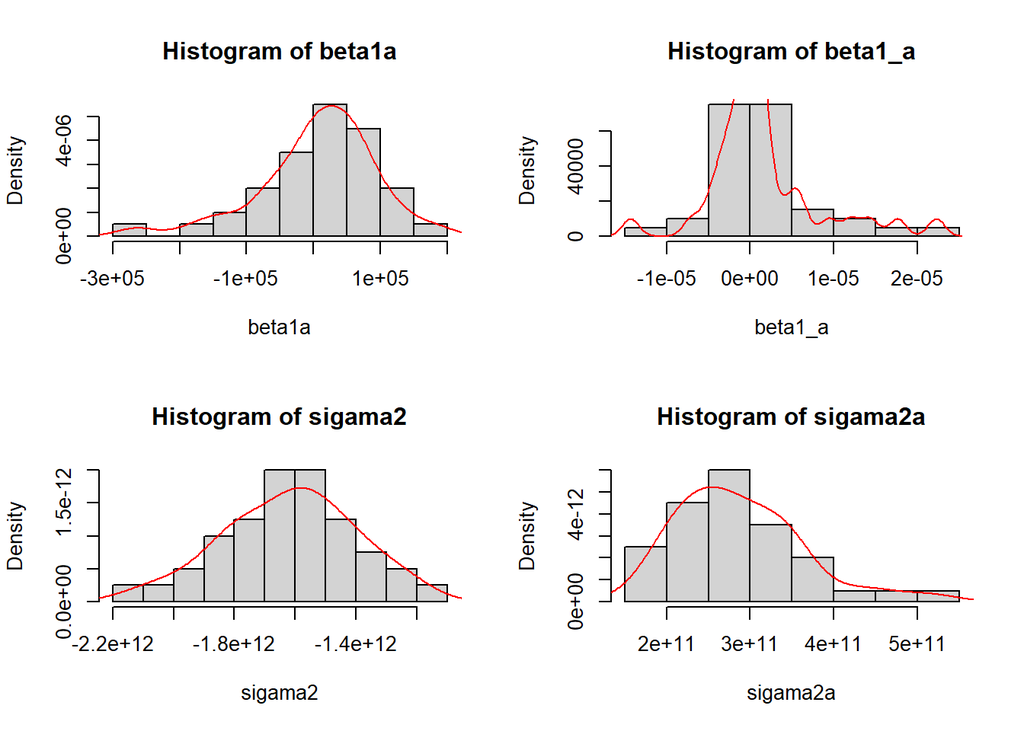

```r
beta1a <- sapply(reg_results3, function(x) x$beta1a)
beta1_a <- sapply(reg_results3, function(x) x$beta1_a)
sigama2 <- sapply(reg_results3, function(x) x$sigma2)
sigama2a <- sapply(reg_results3, function(x) x$sigma2a)
par(mfrow = c(2, 2))

hist(beta1a, freq = FALSE, main = "Histogram of beta1a")
lines(density(beta1a), col = "red")

hist(beta1_a, freq = FALSE, main = "Histogram of beta1_a")
lines(density(beta1_a), col = "red")

hist(sigama2, freq = FALSE, main = "Histogram of sigama2")
lines(density(sigama2), col = "red")

hist(sigama2a, freq = FALSE, main = "Histogram of sigama2a")
lines(density(sigama2a), col = "red")
```

## Jackknife

```r
n <- nrow(result1)
numeric(n)
```

```
##  [1] 0 0 0 0 0 0 0 0 0 0 0 0 0 0 0 0 0 0 0 0 0 0 0 0 0 0 0 0 0 0 0 0 0 0 0 0 0 0
## [39] 0 0
```

```r
result1<-data.frame(result1)
result1
```

```
##         beta1a       beta1_a        sigma2      sigma2a
## 1     1981.075  3.396594e-07 -1.419845e+12 328385160336
## 2    65749.124  1.515133e-06 -1.666583e+12 288656483902
## 3    23959.768 -4.177063e-07 -1.629479e+12 264534755663
## 4   108655.680 -5.087637e-06 -1.803161e+12 309594041790
## 5   143606.205 -3.042091e-06 -1.462665e+12 192378396225
## 6  -181425.580  9.702181e-07 -1.760481e+12 246779189382
## 7    26814.855  9.574677e-07 -1.868186e+12 223557021328
## 8   -67819.365 -1.429842e-05 -1.551216e+12 340701415678
## 9   107935.488  1.432770e-05 -1.687784e+12 281923717208
## 10  -25927.190  1.217365e-07 -1.268968e+12 379249665377
## 11   41790.951  3.432838e-06 -1.632284e+12 344623939638
## 12  183553.713  1.030115e-06 -1.813715e+12 230296397169
## 13   27297.733 -4.220633e-07 -1.398783e+12 250402554064
## 14   50050.411  6.261390e-06 -1.197464e+12 166708939588
```

[output cut: 26 more lines]

```r
for (var_name in names(result1)) {
  # Get the variable
  var <- result1[[var_name]]

  # Compute the estimator
  theta_hat <- mean(var)

  # Initialize a vector to store the jackknife estimates
  theta_jacks <- numeric(n)
  theta_jacks
  # Compute the jackknife estimates
  for (i in 1:n) {
    theta_jacks[i] <- mean(var[-i])
  }
  # Compute and print the jackknife estimate of the bias
  bias_jk <- (n - 1) * (mean(theta_jacks) - theta_hat)
  print(paste("Jackknife estimate of bias for", var_name, "is", bias_jk))

  variance_jk <- (n - 1) * mean((theta_jacks - mean(theta_jacks))^2)
  print(paste("Jackknife estimate of variance for", var_name, "is", variance_jk))
}
```

```
## [1] "Jackknife estimate of bias for beta1a is 0"
## [1] "Jackknife estimate of variance for beta1a is 190199817.323048"
## [1] "Jackknife estimate of bias for beta1_a is 0"
## [1] "Jackknife estimate of variance for beta1_a is 1.04278042023227e-12"
## [1] "Jackknife estimate of bias for sigma2 is 0"
## [1] "Jackknife estimate of variance for sigma2 is 1.15943978823488e+21"
## [1] "Jackknife estimate of bias for sigma2a is 0"
## [1] "Jackknife estimate of variance for sigma2a is 1.39793201481531e+20"
```

## Conclusion

Monte Carlo simulations offer the advantage of flexibility and universality. These simulations handle very complex systems which are difficult to model analytically. They can incorporate a large number of variables and model their interactions. However the accuracy of Monte Carlo simulations depends largely on the number of iterations run, which can also increase computational load.

Bootstrap methods involve generating many subsamples from the original data and recalculating the estimator for each subsample. Bootstrapping can estimate the distribution of an estimator when the underlying distribution is unknown or complex. One of the main advantages of bootstrapping is that it makes fewer assumptions about the data compared to other methods. However, similar to Monte Carlo simulations, Bootstrap methods are also computationally intensive,

The jackknife method is another resampling technique that take out one observation at a time from the dataset and recalculating the estimator for bias and MSE. It is relatively simple and computationally efficient, especially compared to Bootstrap. Jackknife can provide robust estimates of bias and variance, even if the data contain outliers. However, it might not be efficient when complex estimators are presented.

In conclusion, the choice between Monte Carlo, bootstrap, and jackknife depends on the specific use case, including the nature of the data, the complexity of the estimator, and the computational resources available.